# Cyclist Project

Fabiano Ju

2024-12-04

### Fast-Tracking Success: Growth Plan for.

# Cyclist.

#### Background explanation.

Cyclistic, a bike-share company based in Chicago, that features more than 5,800 bikes and 600 docking stations.

Cyclistic categorizes its bike users into two groups:

- **Casual rider:** Customers who purchase single-ride or full-day passes.
- **Cyclistic members:** Customers who commit to annual memberships.

The Marketing team is laser-focused on **one clear goal**:  
- Convert casual riders into Cyclistic members through compelling marketing strategies.

### Business task.

To achieve this goal, we need to address the following questions:

1. How do annual members and casual riders use Cyclistic bikes differently?
2. Why would casual riders opt for Cyclistic annual memberships?
3. How can Cyclistic use digital media to influence casual members to become Cyclistic members?

#### Note.

This is ‘Google Data Analytics Professional Certificate’ Capstone project. Cyclistic is a fictional company and the data has been made available by Motivate International Inc. under this [license](https://divvybikes.com/data-license-agreement).

**Data used for this project** Data of 2019-Q4 and 2020-Q1 of Lyft Bikes and Scooters, LLC (“Bikeshare”) that operates the City of Chicago’s (“City”) Divvy bicycle sharing service.

#### Question 1:

## How Are Casual Riders Different from Cyclistic Members?

#### **Who rides more?**

Let’s find out the proportions of total rides taken by casual riders versus members.

```r
dt %>%
  group_by(member_casual) %>%
  summarise(count = n(),
            percentage = (count / nrow(dt)) * 100
            )
```

| member_casual | count | percentage |
| --- | --- | --- |
| casual | 148987 | 13.2506 |
| member | 975392 | 86.7494 |

**Observation**: Annual members dominate, accounting for a whopping 86.7% of total bike usage.

#### Visualizing the Data:

We represent this difference using a bar chart and a pie chart for added pizzazz.

- **Bar Chart**: Depicts total bike usage by membership type.

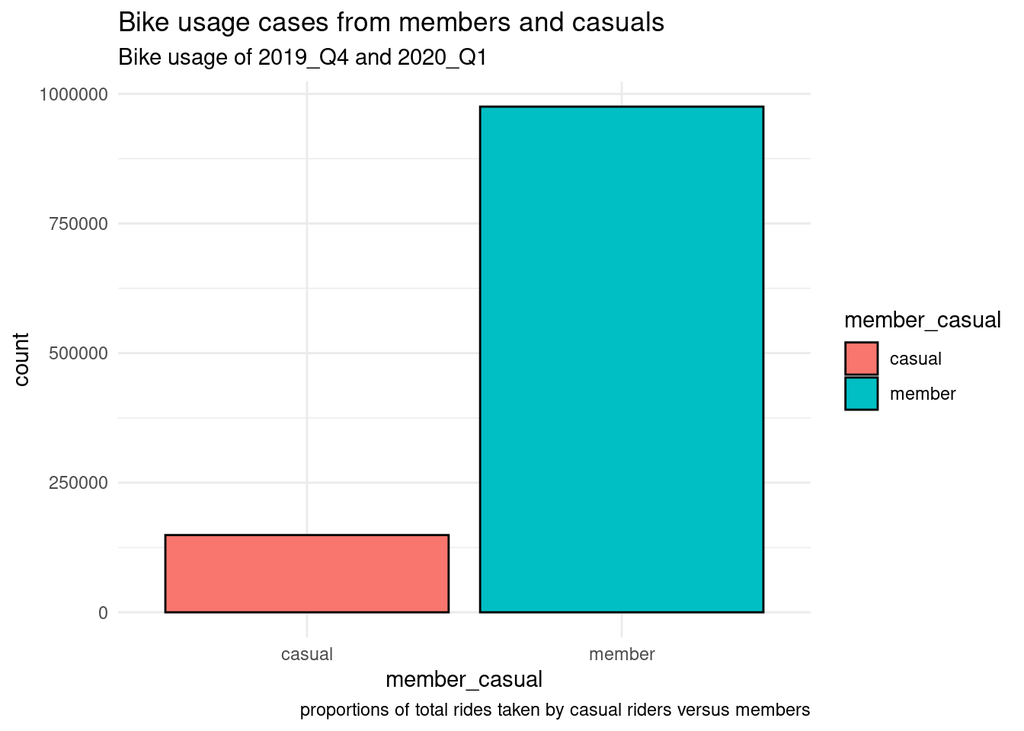

```r
ggplot(data = dt) +
  geom_bar(mapping = aes(x = member_casual, fill = member_casual), color = "black") +
  labs(title = "Bike usage cases from members and casuals", subtitle = "Bike usage of 2019_Q4 and 2020_Q1", caption = "proportions of total rides taken by casual riders versus members") + theme_minimal()
```

- **Pie Chart**: Highlights the same data with a circular flair.

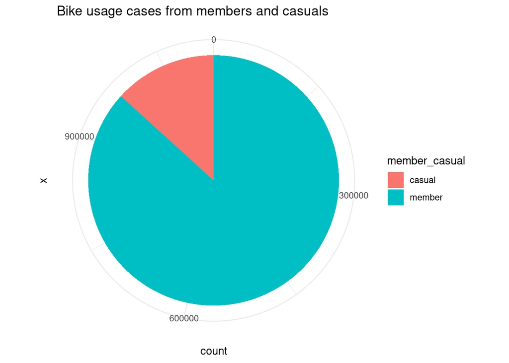

```r
ggplot(data = dt) +
  geom_bar(mapping = aes(x = "", fill = member_casual), width = 1) +
  coord_polar(theta = "y") +
  labs(title = "Bike usage cases from members and casuals") + theme_minimal()
```

#### **How long are their trips?**

Cyclistic Members:

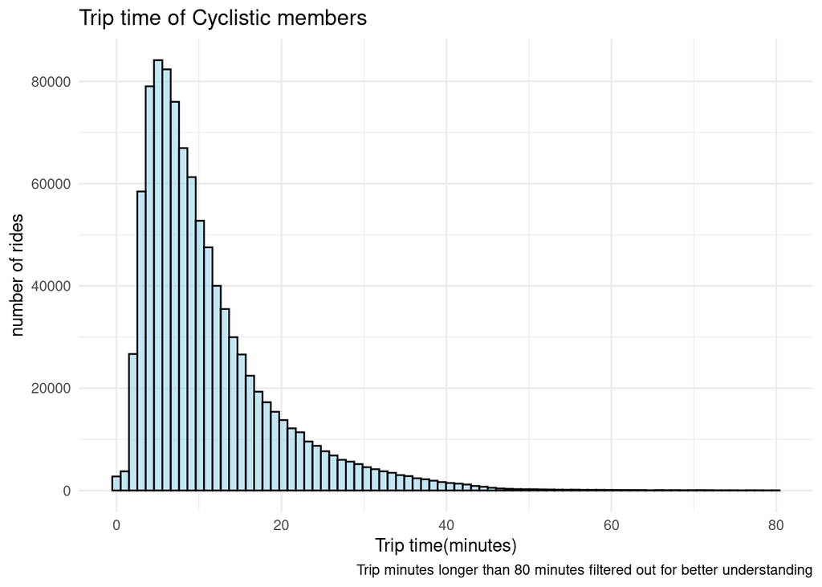

```r
ggplot(data = dt %>% filter(member_casual == "member", trip_minutes <= 80)) +
  geom_histogram(mapping = aes(x = trip_minutes), fill = "skyblue", bins = 80,
                 alpha = 0.5, color = "black") +
  labs(title = "Trip time of Cyclistic members", caption = "Trip minutes longer than 80 minutes filtered out for better understanding", x = "Trip time(minutes)", y = "number of rides") + theme_minimal()
```

Casual Riders:

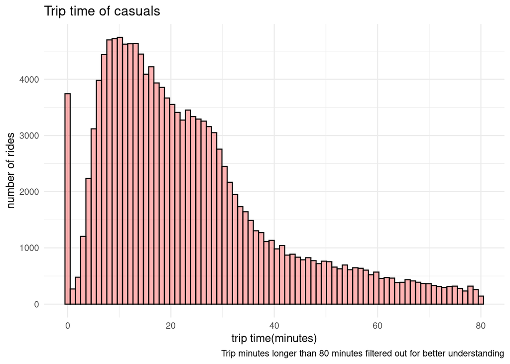

```r
ggplot(data = dt %>% filter(member_casual == "casual", trip_minutes <= 80)) +
  geom_histogram(mapping = aes(x = trip_minutes), fill = "red", bins = 80,
                 alpha = 0.3, color = "black") +
  labs(title = "Trip time of casuals", caption = "Trip minutes longer than 80 minutes filtered out for better understanding", x = "trip time(minutes)", y = "number of rides") + theme_minimal()
```

This table explains us the difference of trip time between Cyclists and casuals. (Time unit is minutes not seconds)

```r
dt %>%
  group_by(member_casual) %>%
  summarise(avg_trip_mins = mean(trip_minutes),
            max_trip_mins = max(trip_minutes),
            min_trip_mins = min(trip_minutes),
            sd_trip_mins = sd(trip_minutes, na.rm = FALSE)
  )
```

| member_casual | avg_trip_mins | max_trip_mins | min_trip_mins | sd_trip_mins |
| --- | --- | --- | --- | --- |
| casual | 26.87527 | 124.98 | 0.00 | 22.67369 |
| member | 11.15449 | 124.80 | 0.02 | 8.51302 |

Cyclistic Members:  
- **Average Trip Time**: 11 minutes.  
- **Trip Length Concentration**: Most trips fall between 5-10 minutes.  
- **Purpose**: Short, focused trips—likely commuting.

Casual Riders:  
- **Average Trip Time**: 26 minutes.  
- **Trip Length Variability**: Trips range from 10 to 30 minutes, with a broader spread.  
- **Purpose**: Leisure or athletic activity.

**Insight**: Members’ shorter trip times indicate purposeful rides, while casuals take their time, enjoying the ride.

### **When Do They Ride?**

#### **Weekday Usage**:

```r
dt$weekday <- factor(dt$weekday, levels = c("Monday", "Tuesday",
                                            "Wednesday", "Thursday", "Friday",
                                            "Saturday", "Sunday"))
```

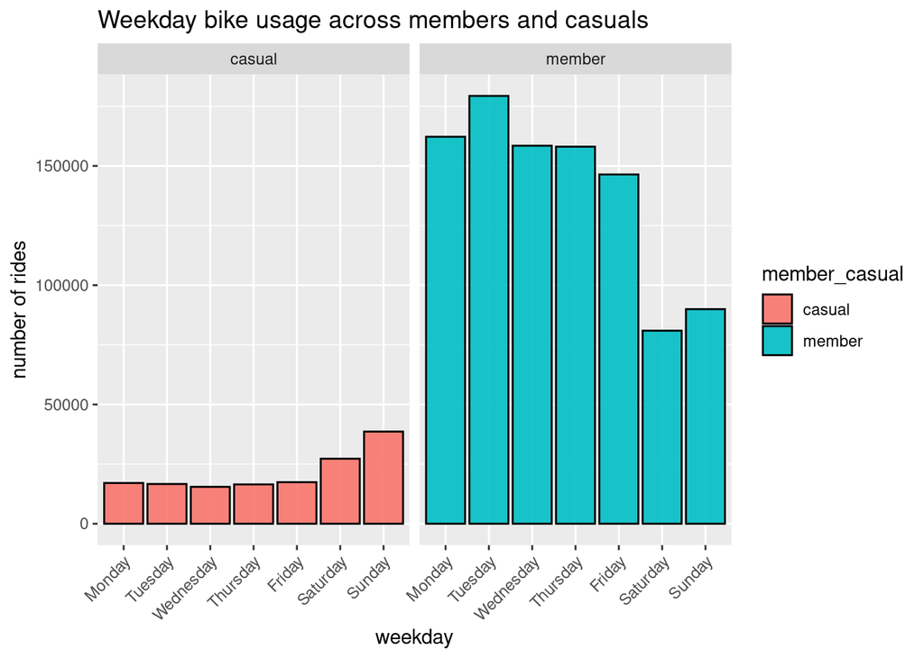

```r
ggplot(data = dt) +
  geom_bar(mapping = aes(x= weekday, fill = member_casual), color = "black", alpha = 0.9) +
  facet_wrap(~member_casual) +
  labs(title = "Weekday bike usage across members and casuals", y = "number of rides") +
  theme(axis.text.x = element_text(angle = 45, hjust = 1))
```

- **Members**: Peak on weekdays—classic commuting patterns.  
- **Casuals**: Shine on weekends, likely enjoying the Chicago scenery.

#### **Daily Usage Trends**:

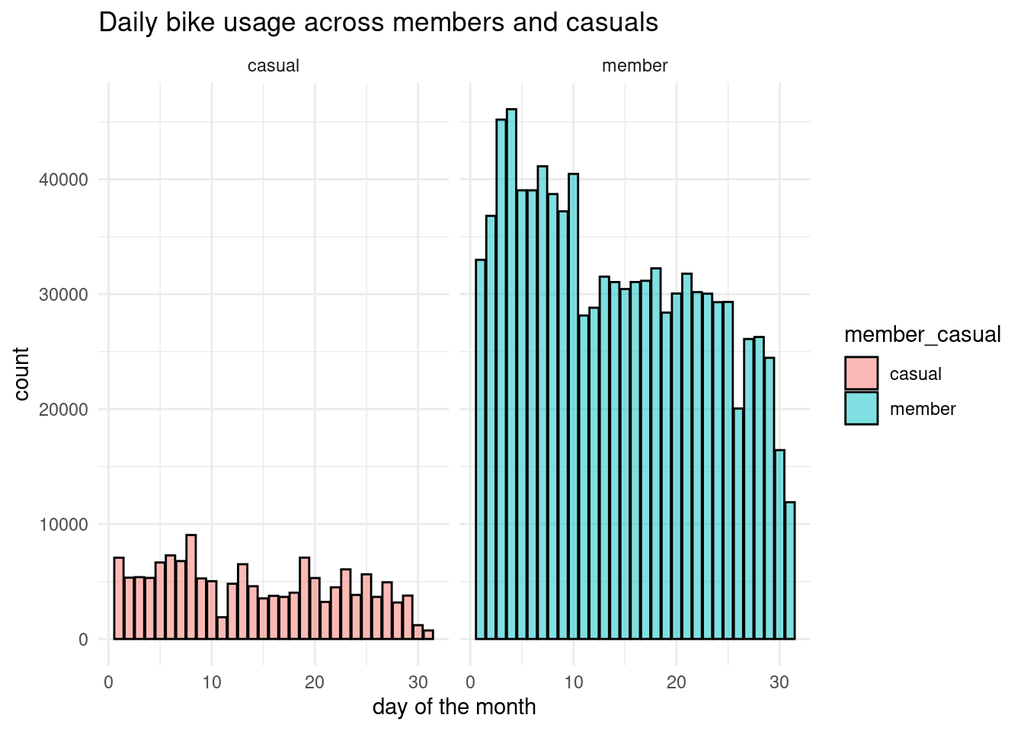

```r
ggplot(data = dt) +
  geom_bar(mapping = aes(x= day, fill = member_casual), color = "black", alpha = 0.5) +
  facet_wrap(~member_casual) +
  labs(title = "Daily bike usage across members and casuals", x = "day of the month") +
  theme_minimal()
```

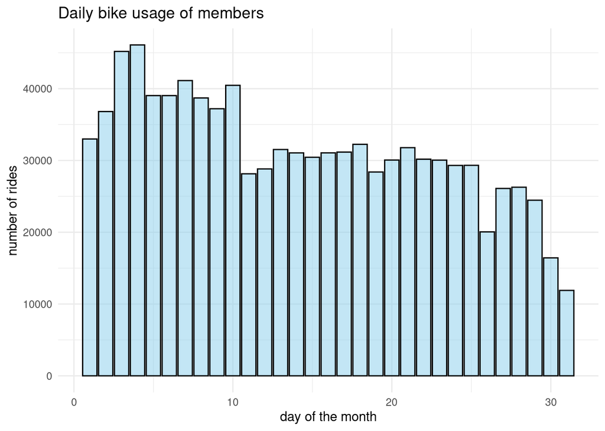

```r
ggplot(data = dt %>% filter(member_casual == "member")) +
  geom_bar(mapping = aes(x= day), fill = "skyblue", color = "black", alpha = 0.5) +
  labs(title = "Daily bike usage of members", x = "day of the month", y = "number of rides") +
  theme_minimal()
```

- Casuals: Fluctuations suggest more spontaneous rides.

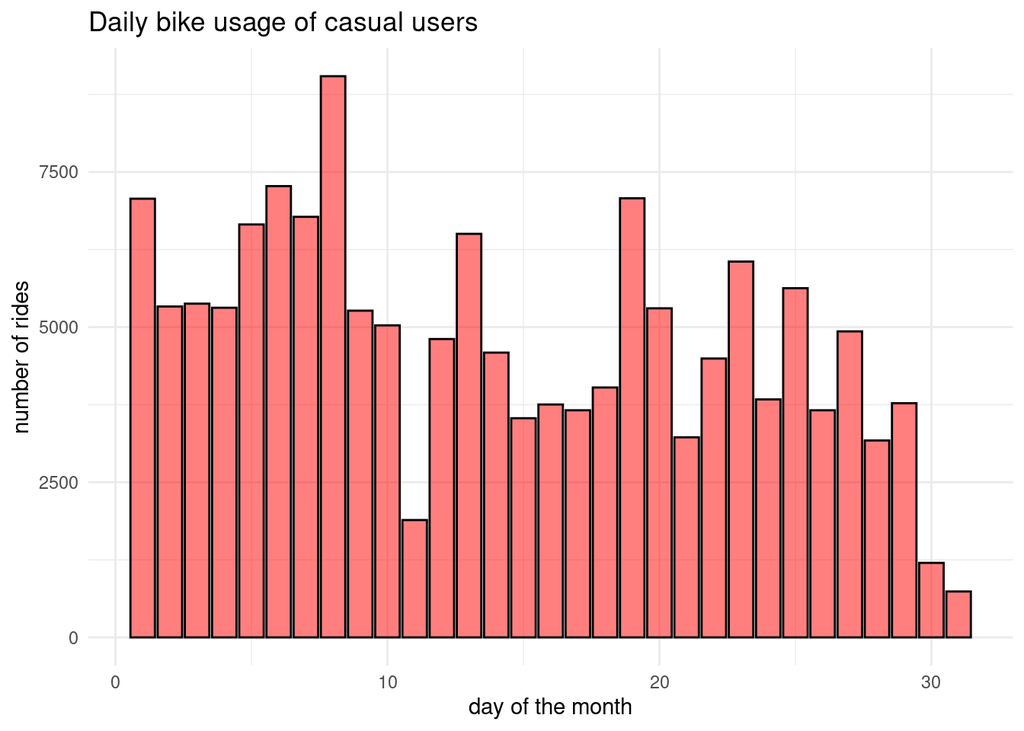

```r
ggplot(data = dt %>% filter(member_casual == "casual")) +
  geom_bar(mapping = aes(x= day), fill = "red", color = "black", alpha = 0.5 ) +
  labs(title = "Daily bike usage of casual users", x = "day of the month", y = "number of rides") +
  theme_minimal()
```

#### **Monthly Trends**:

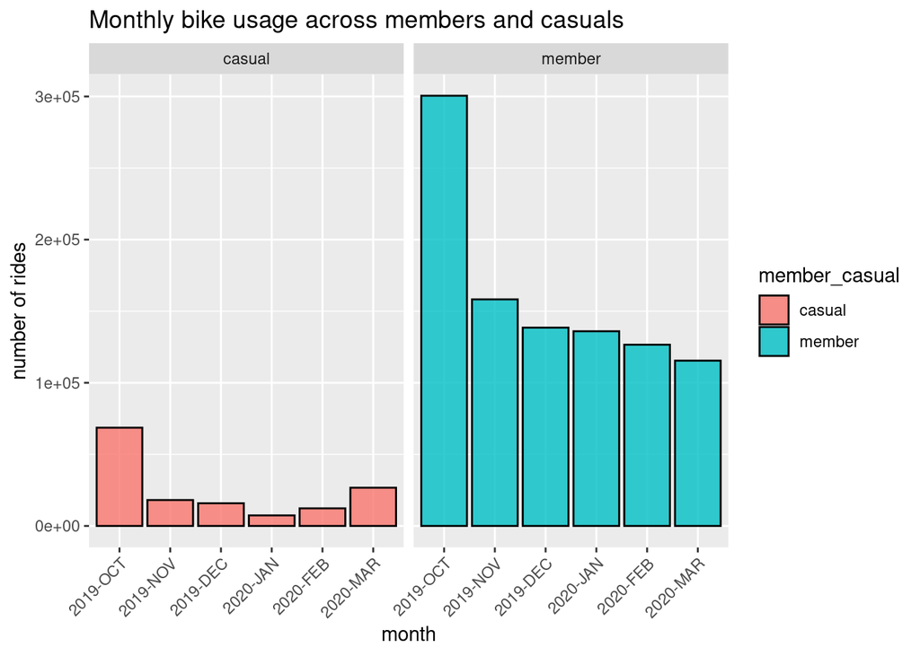

```r
ggplot(data = dt) +
  geom_bar(mapping = aes(x= month, fill = member_casual), color = "black", alpha = 0.8) +
  facet_wrap(~member_casual) +
  labs(title = "Monthly bike usage across members and casuals", y = "number of rides") +
  theme(axis.text.x = element_text(angle = 45, hjust = 1))
```

- Both groups show declining usage after October 2019.  
- But casuals display a slight uptick in March 2020, potentially influenced by marketing efforts.

### **What Time of Day Do They Ride?**

This graph shows when they started a bike ride:

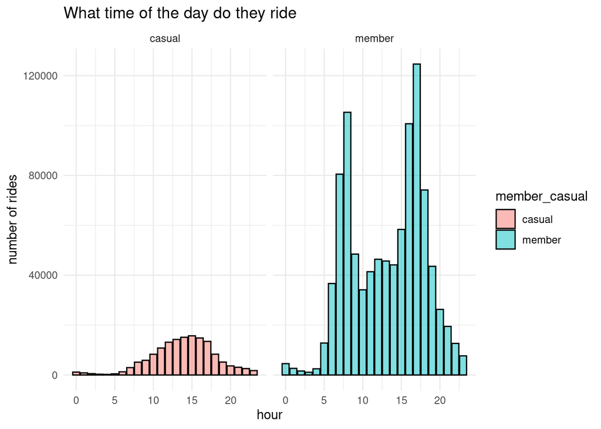

```r
ggplot(data = dt) +
  geom_bar(mapping = aes(x= hour, fill = member_casual), color = "black", alpha = 0.5) +
  facet_wrap(~member_casual) +
  labs(title = "What time of the day do they ride", y = "number of rides") +
  theme_minimal()
```

We can clearly see differences in bike usage pattern here. Let’s take a more closer look:

Cyclists:

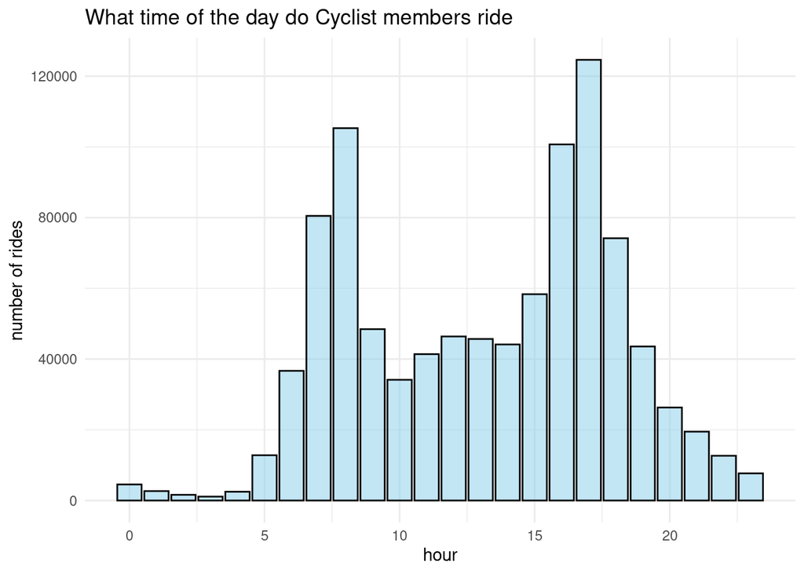

```r
ggplot(data = dt %>% filter(member_casual == "member")) +
  geom_bar(mapping = aes(x= hour), fill = "skyblue", color = "black", alpha = 0.5 ) +
  labs(title = "What time of the day do Cyclist members ride", y = "number of rides") +
  theme_minimal()
```

Casuals show a different pattern:

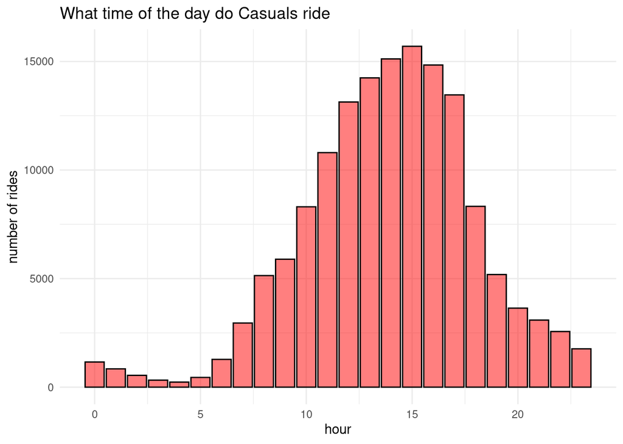

```r
ggplot(data = dt %>% filter(member_casual == "casual")) +
  geom_bar(mapping = aes(x= hour), fill = "red", color = "black", alpha = 0.5 ) +
  labs(title = "What time of the day do Casuals ride", y = "number of rides") +
  theme_minimal()
```

**Members**: Peak at 8 AM and 5 PM—undeniable commuter hours.

**Casuals**: Love their afternoon rides, especially on weekends.

By now we can answer to the business questions.

### How do annual members and casual riders use Cyclistic bikes differently?

Casual Riders:  
- **Average Trip Time**: 26 minutes.  
- **Trip Length Variability**: Trips range from 10 to 30 minutes, with a broader spread.  
- **What time of the day they ride**: Mostly in the afternoons.  
- **Purpose**: Leisure or athletic activity.

**Insight**: Members’ shorter trip times indicate purposeful rides, while casuals take their time, enjoying the ride.

#### Let’s discover more about the Cyclist members. This will allow us to answer better other business questions.

#### Who are Cyclist members?

**Are they men or women?**

```r
gender_summary <- dt %>%
  filter(member_casual == "member") %>%
  drop_na(gender) %>%
  group_by(gender) %>%
  summarise(count = n(), .groups = "drop") %>%
  mutate(percentage = (count / sum(count)) * 100 )
```

This table shows whether man or woman ride more Cyclist’s bike:

```r
print(gender_summary)
```

```
## # A tibble: 2 × 3
##   gender  count percentage
##   <chr>   <int>      <dbl>
## 1 Female 137184       23.2
## 2 Male   455091       76.8
```

**How old are they?**

The oldest rider is born in 1899 and the youngest one is born in 2003.

```r
dt %>%
  filter(member_casual == "member") %>%
  drop_na(birthyear) %>%
  summarise(oldest = min(birthyear),
            youngest = max(birthyear))
```

| oldest | youngest |
| --- | --- |
| 1899 | 2003 |

```r
# Create a new data frame with 10-year intervals
grouped_birthyears <- dt %>%
  select(member_casual, birthyear) %>%
  filter(member_casual == "member") %>%
  drop_na(birthyear) %>%
  mutate(birthyear_group = cut(birthyear,
                               breaks = seq(1890, 2010, by = 10),
                               labels = paste(seq(1890, 2000, by = 10),
                                              seq(1899, 2009, by = 10), sep = "-"),
                               include.lowest = TRUE))
```

```r
dt <- dt %>%
  mutate(birthyear_group = cut(birthyear,
                               breaks = seq(1890, 2010, by = 10),
                               labels = paste(seq(1890, 2000, by = 10),
                                              seq(1899, 2009, by = 10), sep = "-"),
                               include.lowest = TRUE))
```

This table show Cyclist member’s age group, and how many riders fall into each group.

```r
grouped_birthyears %>%
  group_by(birthyear_group) %>%
  summarise(count = n(), .groups = "drop") %>%
  mutate(percentage = (count / sum(count)) * 100 )
```

| birthyear_group | count | percentage |
| --- | --- | --- |
| 1890-1899 | 77 | 0.01290708 |
| 1900-1909 | 100 | 0.01676244 |
| 1920-1929 | 115 | 0.01927680 |
| 1930-1939 | 68 | 0.01139846 |
| 1940-1949 | 2242 | 0.37581382 |
| 1950-1959 | 26111 | 4.37683968 |
| 1960-1969 | 63169 | 10.58866323 |
| 1970-1979 | 88231 | 14.78966495 |
| 1980-1989 | 228348 | 38.27668747 |
| 1990-1999 | 184831 | 30.98217818 |

[output cut: 1 more lines]

This graph allows us to see our bike rider’s age:

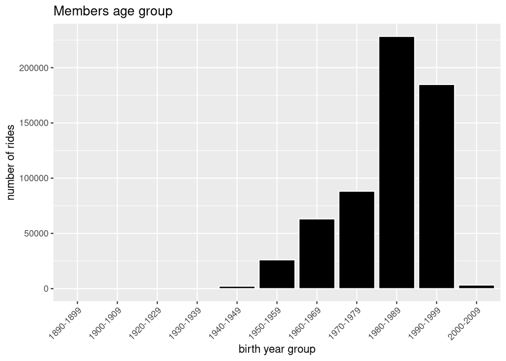

```r
ggplot(data = dt %>% filter(member_casual == "member") %>% drop_na(birthyear)) +
  geom_bar(mapping = aes(x = birthyear_group), fill = "black", color = "white", alpha = 1) +
  labs(title = "Members age group", x = "birth year group", y = "number of rides") +
  theme(axis.text.x = element_text(angle = 45, hjust = 1))
```

Our users are millennials, and men. This age group also let us know that Cyclist members use bike to commute to their workplace.

We therefore can know that the top 20 stations are mostly in workplace area.

```r
dt_station <- dt %>%
  group_by(start_station_name) %>%
  summarise(count = n()) %>%
  arrange(desc(count)) %>%
  slice_head(n = 20)
```

This table shows the top 20 most frequently used bike stations. We can know that they are mostly on the center of Chicago, nearby workplace area.

```r
print(dt_station)
```

```
## # A tibble: 20 × 2
##    start_station_name           count
##    <chr>                        <int>
##  1 Canal St & Adams St          20721
##  2 Clinton St & Madison St      17341
##  3 Clinton St & Washington Blvd 15752
##  4 Columbus Dr & Randolph St    12085
##  5 Kingsbury St & Kinzie St     11924
##  6 Franklin St & Monroe St      10523
##  7 Michigan Ave & Washington St  9498
##  8 Daley Center Plaza            9382
##  9 Streeter Dr & Grand Ave       9070
## 10 Canal St & Madison St         9014
## 11 Clinton St & Lake St          8990
## 12 Larrabee St & Kingsbury St    8855
## 13 LaSalle St & Jackson Blvd     8772
## 14 Lake Shore Dr & Monroe St     8062
## 15 Wells St & Huron St           7870
## 16 Dearborn St & Erie St         7865
## 17 Desplaines St & Kinzie St     7739
## 18 Franklin St & Jackson Blvd    7734
## 19 Clark St & Elm St             7649
## 20 Michigan Ave & Lake St        7604
```

Therefore, we can answer to other key questions:

### Question 2: Why Would Casual Riders Buy Annual Memberships?

To effectively target casual riders, we need to understand their demographics:

- **Age**: Millennials dominate.
- **Gender**: Men ride significantly more (76.8% of member rides).
- **Location**: They likely live within 2.5 km of their workplace in Chicago.
- **Preference**: They enjoy biking as a refreshing commute alternative.

Cyclistic’s extensive network of over 600 docking stations and 5,800 bikes conveniently covers Chicago’s workplace hotspots, making it a no-brainer for potential members.

### Question 3: How Can Cyclistic Use Digital Media to Convert Casual Riders?

The marketing strategy should focus on:  
1. **Highlighting Convenience**: Showcase the vast dock network near workplaces and neighborhoods.  
2. **Strategic Timing**: Deploy ads during commute hours to capture the attention of potential members.  
3. **Content Messaging**: Emphasize convenience and benefits of Cyclistic as commuting alternative.

**Conclusion**:  
Cyclistic’s marketing team is now equipped to craft a winning strategy to convert casual riders into loyal members. Let’s get rolling! 🚴‍♂️